# EVS Dynamic Report

Sarah Gonyo

2023-05-03

# Overview

The purpose of this project is to create an interactive [shiny app](https://www.shinyapps.io/admin/#/application/9020621) to understand attitudes towards gender roles and immigration using data from the European Value Study (EVS) from 2017. The EVS is a large-scale, cross-national and longitudinal survey research on how Europeans think about family, work, religion, politics, and society. Visit [European Value Study](https://search.gesis.org/research_data/ZA7500#variables%7Cexploredata-ZA7500_Varv80%7C0%7Cvariable_order%7Casc%7Cv80) for more information.

The two variables of interest are agreement with the following statements:

- When a mother works for pay, the children suffer
- When jobs are scarce, employers should give priority to [NATIONALITY] people over immigrants

Two tabs are shown in the app. The first tab shows graphs exploring the relationship between the selected outcome variable and three controls: age, education, and sex. The second tab shows the coefficients and residuals plot of a regression analysis between the selected outcome variable and selected control variables.

Four inputs are required to use this app. First, select a country from the drop-down menu below. Next, select between two outcome variables. Then, select sex and/or education as your control variables (age is included by default). Finally, select the number of age polynomials you would like to include in the regression (e.g., selecting 3 includes age, age^2, and age^3).

# Main Findings

Figure 1 shows the relationship between the selected variable of interest and age, education, and sex.

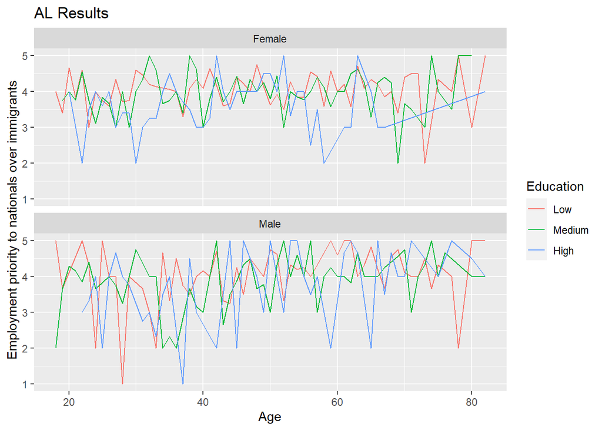

The regression model below explains the effects of selected inputs on the selected variable of interest.

Regression Results

|  | Model 1 |
| --- | --- |
| (Intercept) | 3.99*** |
|  | (0.03) |
| poly(age, 1) | 5.01*** |
|  | (1.09) |
| R<sup>2</sup> | 0.01 |
| Adj. R<sup>2</sup> | 0.01 |
| Num. obs. | 1417 |

***p < 0.001; **p < 0.01; *p < 0.05

Finally, the figure below shows a scatterplot of the predicted versus the residuals from the regression.

[figure not shown]